# Stopword

Low Chi Ting

10/3/2021

```r
library(tidyverse)
library(stopwords)
length(stopwords(source = "smart"))
```

```
## [1] 571
```

```r
length(stopwords(source = "snowball"))
```

```
## [1] 175
```

```r
length(stopwords(source = "stopwords-iso"))
```

```
## [1] 1298
```

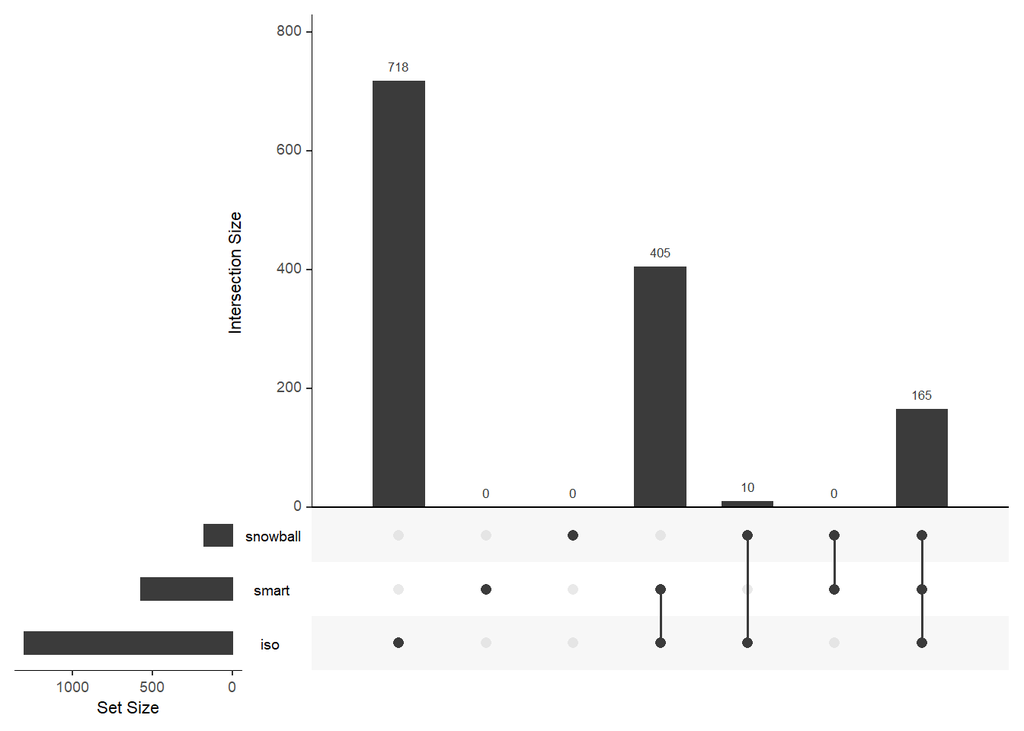

Set intersections for three common stop word lists visualized as an UpSet plot

```r
setdiff(stopwords(source = "snowball"),
        stopwords(source = "smart"))
```

```
##  [1] "she's"   "he'd"    "she'd"   "he'll"   "she'll"  "shan't"  "mustn't"
##  [8] "when's"  "why's"   "how's"
```

```r
str_subset(stopwords(source = "smart"), "'")
```

```
##  [1] "a's"       "ain't"     "aren't"    "c'mon"     "c's"       "can't"
##  [7] "couldn't"  "didn't"    "doesn't"   "don't"     "hadn't"    "hasn't"
## [13] "haven't"   "he's"      "here's"    "i'd"       "i'll"      "i'm"
## [19] "i've"      "isn't"     "it'd"      "it'll"     "it's"      "let's"
## [25] "shouldn't" "t's"       "that's"    "there's"   "they'd"    "they'll"
## [31] "they're"   "they've"   "wasn't"    "we'd"      "we'll"     "we're"
## [37] "we've"     "weren't"   "what's"    "where's"   "who's"     "won't"
## [43] "wouldn't"  "you'd"     "you'll"    "you're"    "you've"
```

## Remove stop words

```r
library(hcandersenr)
library(tidyverse)
library(tidytext)

fir_tree <- hca_fairytales() %>%
  filter(book == "The fir tree",
         language == "English")

tidy_fir_tree <- fir_tree %>%
  unnest_tokens(word, text)

tidy_fir_tree %>%
  filter(!(word %in% stopwords(source = "snowball")))
```

```
## # A tibble: 1,547 x 3
##    book         language word
##    <chr>        <chr>    <chr>
##  1 The fir tree English  far
##  2 The fir tree English  forest
##  3 The fir tree English  warm
##  4 The fir tree English  sun
##  5 The fir tree English  fresh
##  6 The fir tree English  air
##  7 The fir tree English  made
##  8 The fir tree English  sweet
##  9 The fir tree English  resting
## 10 The fir tree English  place
## # ... with 1,537 more rows
```

```r
tidy_fir_tree %>%
  anti_join(get_stopwords(source = "snowball"))
```

```
## # A tibble: 1,547 x 3
##    book         language word
##    <chr>        <chr>    <chr>
##  1 The fir tree English  far
##  2 The fir tree English  forest
##  3 The fir tree English  warm
##  4 The fir tree English  sun
##  5 The fir tree English  fresh
##  6 The fir tree English  air
##  7 The fir tree English  made
##  8 The fir tree English  sweet
##  9 The fir tree English  resting
## 10 The fir tree English  place
## # ... with 1,537 more rows
```

It is worth keeping in mind that such a list is not perfect. Depending on how your text was generated or processed, strange tokens can surface as possible stop words due to encoding or optical character recognition errors. Further, these results are based on the corpus of documents we have available, which is potentially biased. In our example here, all the fairy tales were written by the same European white man from the early 1800s.

This bias can be minimized by removing words we would expect to be over-represented or to add words we expect to be under-represented.

Easy examples are to include the complements to the words in the list if they are not already present. Include “big” if “small” is present, “old” if “young” is present. This example list has words associated with women often listed lower in rank than words associated with men. With `"man"` being at rank 79 but `"woman"` at rank 179, choosing a threshold of 100 would lead to only one of these words being included. Depending on how important you think such nouns are going to be in your texts, consider either adding `"woman"` or deleting `"man"`.[^1]

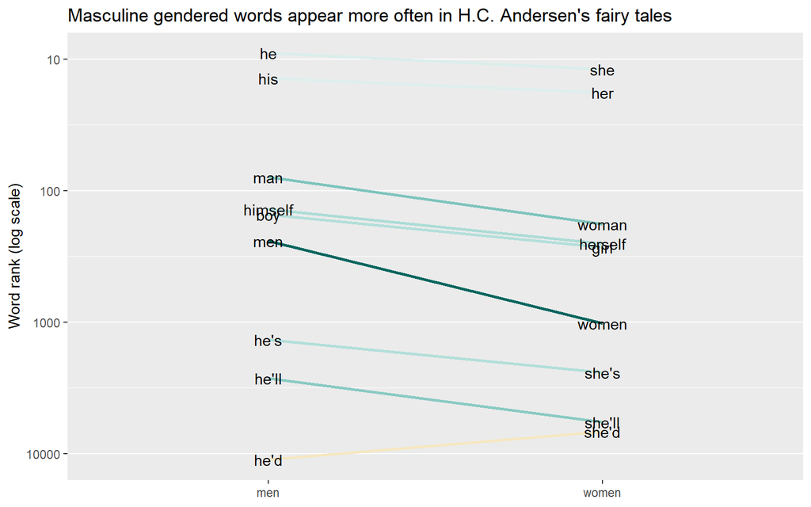

Tokens ranked according to total occurrences, with rank 1 having the most occurrences

Imagine now we would like to create a stop word list that spans multiple different genres, in such a way that the subject-specific stop words don’t overlap. For this case, we would like words to be denoted as a stop word only if it is a stop word in all the genres. You could find the words individually in each genre and use the right intersections. However, that approach might take a substantial amount of time.

Below is a bad approach where we try to create a multi-language list of stop words. To accomplish this we calculate the [*inverse document frequency*](https://www.tidytextmining.com/tfidf.html) (IDF) of each word. The IDF of a word is a quantity that is low for commonly-used words in a collection of documents and high for words not used often in a collection of documents. It is typically defined as

$$idf(\text{term}) = \ln{\left(\frac{n_{\text{documents}}}{n_{\text{documents containing term}}}\right)}$$

If the word “dog” appears in 4 out of 100 documents then it would have an `idf("dog") = log(100/4) = 3.22`, and if the word “cat” appears in 99 out of 100 documents then it would have an `idf("cat") = log(100/99) = 0.01`. Notice how the idf values goes to zero (as a matter of fact when a term appears in all the documents then the idf of that word is 0 `log(100/100) = log(1) = 0`), the more documents it is contained in. What happens if we create a stop word list based on words with the lowest IDF? The following function takes a tokenized dataframe and returns a dataframe with a column for each word and a column for the IDF.

```r
library(rlang)
```

```r
calc_idf <- function(df, word, document) {
  words <- df %>% pull({{word}}) %>% unique()
  n_docs <- length(unique(pull(df, {{document}})))
  n_words <- df %>%
    nest(data = c({{word}})) %>%
    pull(data) %>%
    map_dfc(~ words %in% unique(pull(.x, {{word}}))) %>%
    rowSums()

  tibble(word = words,
         idf = log(n_docs / n_words))
}
```

[figure not shown]

Proportion of words removed for different stop word lists and different document lengths

German Definite Articles (the)

|  | Masculine | Feminine | Neuter | Plural |
| --- | --- | --- | --- | --- |
| Nominative | der | die | das | die |
| Accusative | den | die | das | die |
| Dative | dem | der | dem | den |
| Genitive | des | der | des | der |

German Indefinite Articles (a/an)

|  | Masculine | Feminine | Neuter |
| --- | --- | --- | --- |
| Nominative | ein | eine | ein |
| Accusative | einen | eine | ein |
| Dative | einem | einer | einem |
| Genitive | eines | einer | eines |

[^1]: On the other hand, the more biased stop word list may be helpful when modeling a corpus with gender imbalance, depending on your goal; words like “she” and “her” can identify where women are mentioned.